# Trabalho de Grupo Nº2 — Técnicas de Classificação e Análise de Dados 2025

[figure not shown]

# Análise de Clustering no Dataset Glass para Identificação de Tipos de Vidro

# 1. Introdução

## 1.1 Motivação e Contexto

O objetivo deste trabalho é aplicar técnicas de clustering a um conjunto de dados sobre vidros, de modo a identificar padrões e semelhanças entre diferentes tipos de vidro, através das suas propriedades químicas.

O trabalho foi realizado no âmbito da unidade curricular **Técnicas de Classificação e Análise de Dados (TCAD)** do **Mestrado em Computação Avançada** na **Universidade do Minho**.

## 1.2 Objetivos do Trabalho

Consideramos os seguintes objetivos principais:

- Identificar agrupamentos naturais a partir das variáveis de composição química (RI, Na, Mg, Al, Si, K, Ca, Ba, Fe).
- Construir o perfil químico médio de cada cluster.
- Validar a separação comparando os clusters com o rótulo original (`Type_Glass`, usado apenas na validação/interpretação).

# 2. Descrição do Dataset

O conjunto de dados utilizado foi o Glass Identification, e encontra-se disponível no [UCI Machine Learning Repository](https://archive.ics.uci.edu/dataset/42/glass+identification). Originalmente o conjunto de dados foi criado como apoio a investigações criminais, nomeadamente para identificar o tipo de vidro encontrado em cenas de crime.

O conjunto de dados contém **11 variáveis**. A variável `ID` que serve como identificador da observação não será utilizada, logo apenas existem **10 variáveis efetivas.** Destas dez variáveis existem nove que são variáveis preditoras e correspondem a propriedades químicas do vidro. A variável `Type of Glass` é a variável resposta e corresponde ao grupo a que cada vidro pertence.

**Descrição das variáveis preditoras:**

- `RI` - Índice de refração do vidro.
- `Na`, `Mg`, `Al`, `Si`, `K`, `Ca`, `Ba`, `Fe` - Diferentes elementos químicos encontrados no vidro.

# 3. Preparação e Limpeza dos Dados

## 3.1 Importar o Dataset

Inicialmente, importamos o conjunto de dados e eliminamos a variável `ID`, pois ela não contribui para a análise de agrupamentos que será realizada.

```r
# Trazer bibliotecas necessárias
packages <- c(
  "tidyverse", "readxl", "janitor", "GGally",
  "factoextra", "cluster", "scales", "knitr", "gridExtra"
)
to_install <- setdiff(packages, rownames(installed.packages()))
if (length(to_install) > 0) install.packages(to_install)
invisible(lapply(packages, library, character.only = TRUE))
theme_set(theme_minimal())
set.seed(123)

# Importar o dataset
glass_df <- read_excel("data/glass.xlsx")

# Mudar o nome da coluna 'Type of Glass' para 'tipo_vidro'
colnames(glass_df)[11] <- "tipo_vidro"

# Remoção da variável ID
glass_df$ID <- NULL
```

## 3.2 Limpeza dos dados

Decidimos verificar se existem valores omissos (NA) no conjunto de dados.

```r
# Verificação de valores omissos no dataset completo
omissos <- glass_df %>%
  summarise(across(everything(), ~ sum(is.na(.)))) %>%
  pivot_longer(everything(), names_to = "variavel", values_to = "true")

if (any(omissos$true > 0)) {
  warning("Existem valores em falta; considere imputação antes do clustering.")
} else {
  message("Sem valores em falta; prosseguir para escala e clustering.")
}
```

```
## Sem valores em falta; prosseguir para escala e clustering.
```

Após a verificação confirma-se que **não existem** valores omissos (NA).

# 4. Análise Exploratória dos Dados

Durante a análise exploratória de dados (EDA), procurámos compreender a organização e a distribuição dos dados. Com base nesta exploração, identificámos e removemos algumas variáveis que apresentavam pouca relevância para a análise de clusters subsequente, visando melhorar a qualidade e a interpretabilidade dos agrupamentos.

## 4.1 Análise e Interpretação dos Histogramas

Na primeira fase do EDA, fizemos uma análise da distribuição dos histogramas sem/com dependência do tipo de vidro.

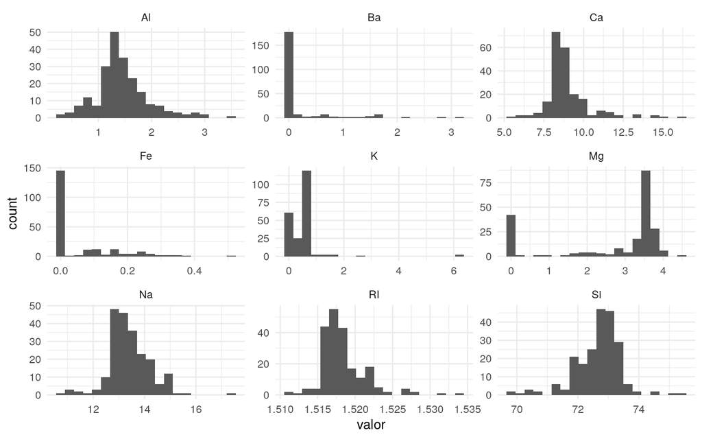

```r
# Distribuição das variáveis preditora
# Dataset sem a variável dependente
glass_dfp <- glass_df %>% select(-tipo_vidro)

glass_long <- glass_dfp %>%
  pivot_longer(cols = everything(), names_to = "variavel", values_to = "valor")
ggplot(glass_long, aes(x = valor)) +
  geom_histogram(bins = 20) +
  facet_wrap(~ variavel, scales = "free") +
  theme_minimal()
```

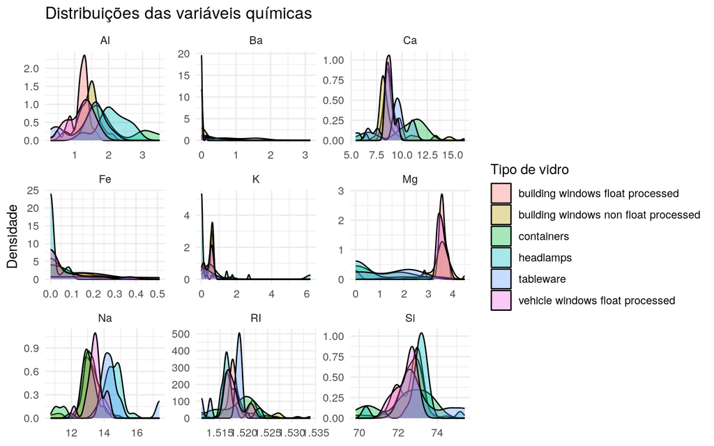

```r
# Distribuição das variáveis preditoras por tipo de vidro
glass_df %>%
  pivot_longer(-tipo_vidro, names_to = "variavel", values_to = "valor") %>%
  ggplot(aes(x = valor, fill = tipo_vidro)) +
  geom_density(alpha = 0.35) +
  facet_wrap(~ variavel, scales = "free") +
  labs(
    title = "Distribuições das variáveis químicas",
    x = NULL, y = "Densidade", fill = "Tipo de vidro"
  )
```

Na maior parte dos histogramas verifica-se uma distribuição central, com uma certa tendência a normalidade com um certo enviesamento. Em exceção a esta regra geral, temos 4 elementos químicos:

- Magnésio
- Bário
- Potássio
- Ferro

De forma contrária aos três restantes elementos, o magnésio apresenta um histograma fortemente enviesado à esquerda. A partir da observação dos histogramas pelos diferentes tipos de vidro verifica-se que ambos os elementos bário e ferro apresentam na sua maioria observações sem concentração do mesmo elemento. A presença de variáveis com cardinalidade igual a um neste caso, pode prejudicar um algoritmo de K-Means, isto porque não servem para distinção entre diferentes grupos. Tendo isto em conta decidimos investigar se a remoção das duas variáveis fará sentido no contexto do problema.

## 4.2 Investigação sobre a Utilidade do Bário e do Ferro no Contexto do Problema

Nesta análise consideramos importante manter as variáveis que possam entregar informação específica para um dos tipos de vidro, e assim caracterizar e distinguir esse tipo de vidro dos restantes. Decidimos investigar a distribuição dos dados para cada tipo de vidro destes dois elementos químicos sobre a forma de um boxplot.

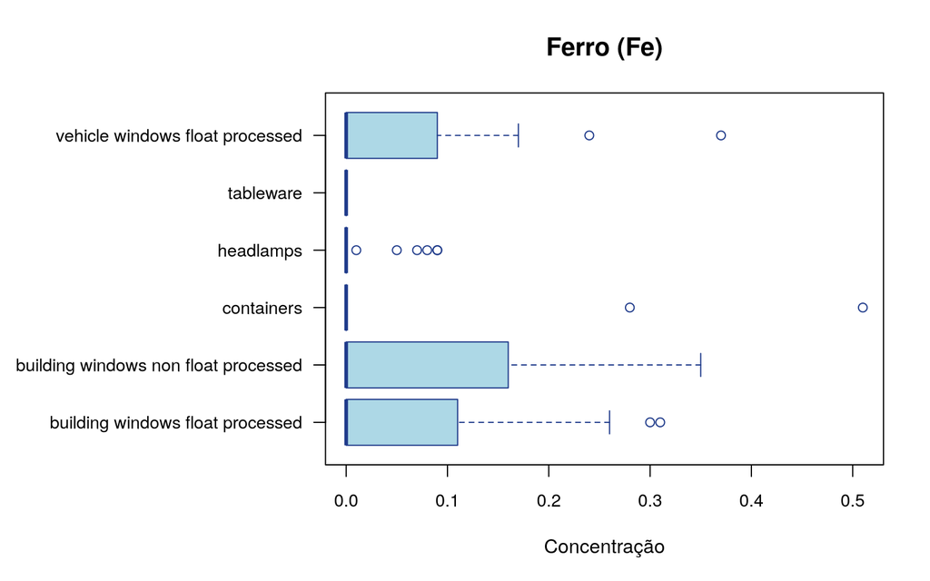

```r
# Boxplot do Ferro (Fe)
par(mar = c(5, 14, 4, 2))
boxplot(Fe ~ tipo_vidro,
        data = glass_df,
        horizontal = TRUE,
        col = "#add8e6",
        border = "#1e3a8a",
        main = "Ferro (Fe)",
        xlab = "Concentração",
        ylab = "",
        las = 1,
        cex.axis = 0.9,
        cex.main = 1.3)
```

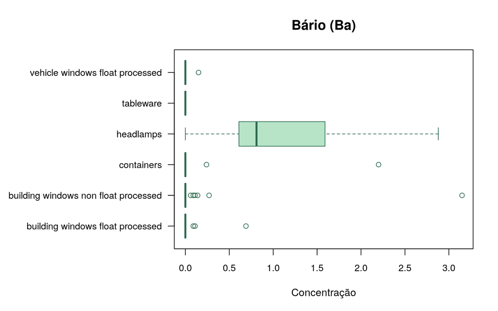

```r
# Boxplot do Bário (Ba)
par(mar = c(5, 14, 4, 2))
boxplot(Ba ~ tipo_vidro,
        data = glass_df,
        horizontal = TRUE,
        col = "#b7e4c7",
        border = "#2d6a4f",
        main = "Bário (Ba)",
        xlab = "Concentração",
        ylab = "",
        las = 1,
        cex.axis = 0.9,
        cex.main = 1.3)
```

A partir dos boxplots, verifica-se que a concentração do elemento químico ferro (Fe) é, em média, nula na maioria dos tipos de vidro, apresentando algumas exceções em determinados grupos. Esta característica limita o poder discriminativo do ferro na distinção entre os diferentes tipos de vidro. Por outro lado, o bário (Ba) apresenta valores nulos, em média, para praticamente todos os tipos de vidro, exceto nos vidros do tipo *headlamps*. Apesar da elevada proporção de zeros nesta variável ao longo do conjunto de dados, a associação evidente com os vidros *headlamps* sugere que o bário possui um potencial valor discriminativo significativo para este grupo específico. Decidimos excluir o elemento químico bário da análise, pois a sua inclusão leva a uma silhueta ótima com apenas dois clusters: um grupo contendo vidros com bário e outro sem. Embora a presença do bário facilite a identificação específica de vidros do tipo *headlamps*, optámos por priorizar uma segmentação mais detalhada, capaz de distinguir um maior número de tipos de vidro. Assim, a remoção do bário permite uma análise mais abrangente da diversidade química presente no conjunto de dados.

## 4.3 Análise de Outliers

A segunda princpal fase é a análise de valores extremos no conjunto de dados que possam afetar de forma negativa a qualidade do modelo de K-Means, ou seja, impactar a discriminação entre os diferentes tipos de vidro existentes.

Nesta análise, considerou-se a remoção apenas daqueles outliers cuja exclusão seja justificada semanticamente, evitando intervenções baseadas exclusivamente em critérios numéricos.

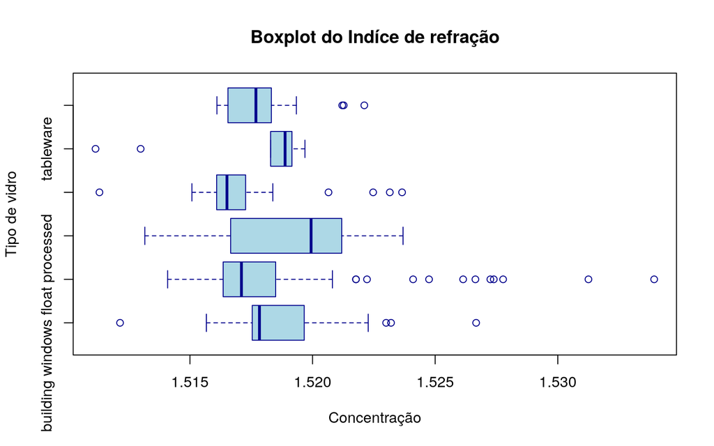

```r
# Boxplot para o Indíce de refração em relação ao tipo de vidro
boxplot(RI ~ tipo_vidro,
        data = glass_df,
        main = "Boxplot do Indíce de refração",
        xlab = "Concentração",
        ylab = "Tipo de vidro",
        col = "lightblue",
        border = "darkblue",
        horizontal = TRUE)
```

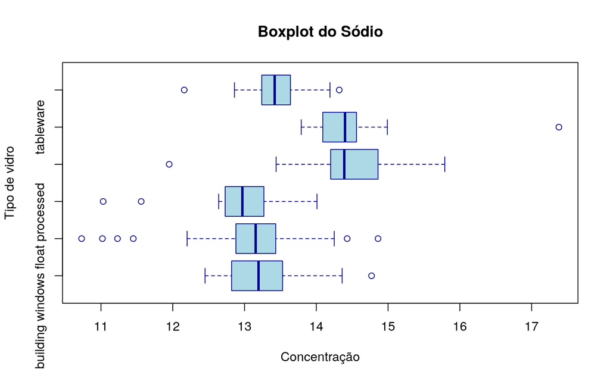

```r
# Boxplot para o sódio em relação ao tipo de vidro
boxplot(Na ~ tipo_vidro,
        data = glass_df,
        main = "Boxplot do Sódio",
        xlab = "Concentração",
        ylab = "Tipo de vidro",
        col = "lightblue",
        border = "darkblue",
        horizontal = TRUE)
```

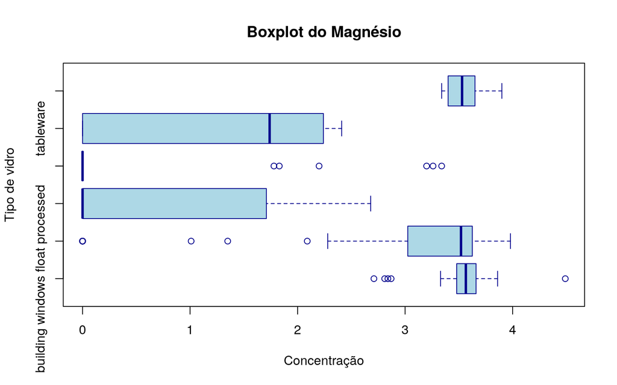

```r
# Boxplot para o Magnésio em relação ao tipo de vidro
boxplot(Mg ~ tipo_vidro,
        data = glass_df,
        main = "Boxplot do Magnésio",
        xlab = "Concentração",
        ylab = "Tipo de vidro",
        col = "lightblue",
        border = "darkblue",
        horizontal = TRUE)
```

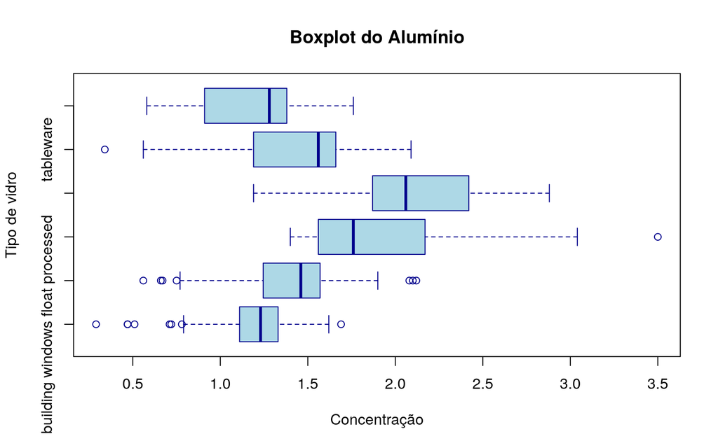

```r
# Boxplot para o Aluminio em relação ao tipo de vidro
boxplot(Al~ tipo_vidro,
        data = glass_df,
        main = "Boxplot do Alumínio",
        xlab = "Concentração",
        ylab = "Tipo de vidro",
        col = "lightblue",
        border = "darkblue",
        horizontal = TRUE)
```

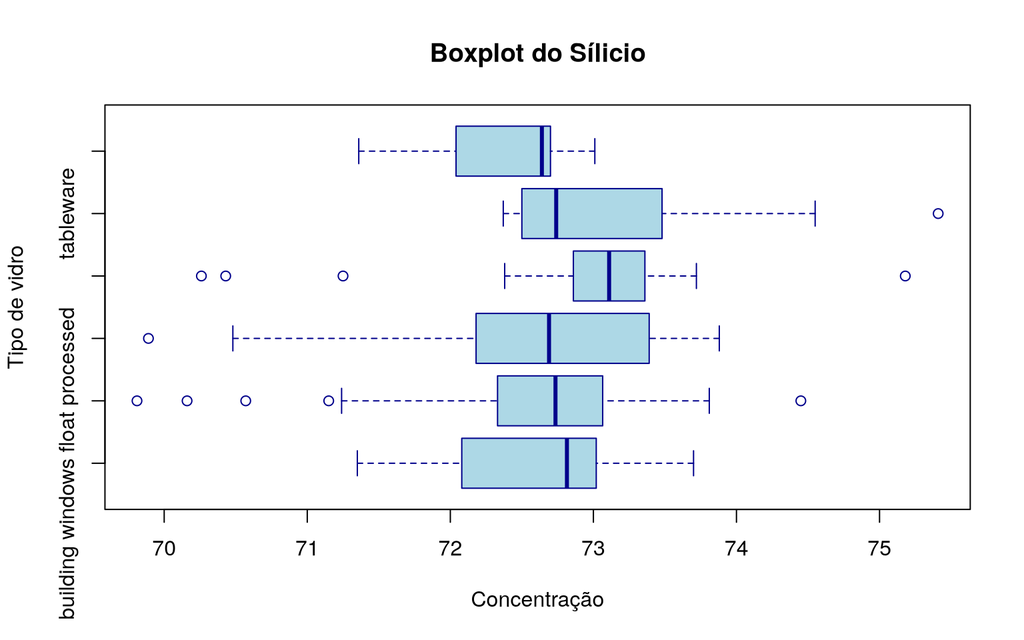

```r
# Boxplot para o Sílicio em relação ao tipo de vidro
boxplot(Si ~ tipo_vidro,
        data = glass_df,
        main = "Boxplot do Sílicio",
        xlab = "Concentração",
        ylab = "Tipo de vidro",
        col = "lightblue",
        border = "darkblue",
        horizontal = TRUE)
```

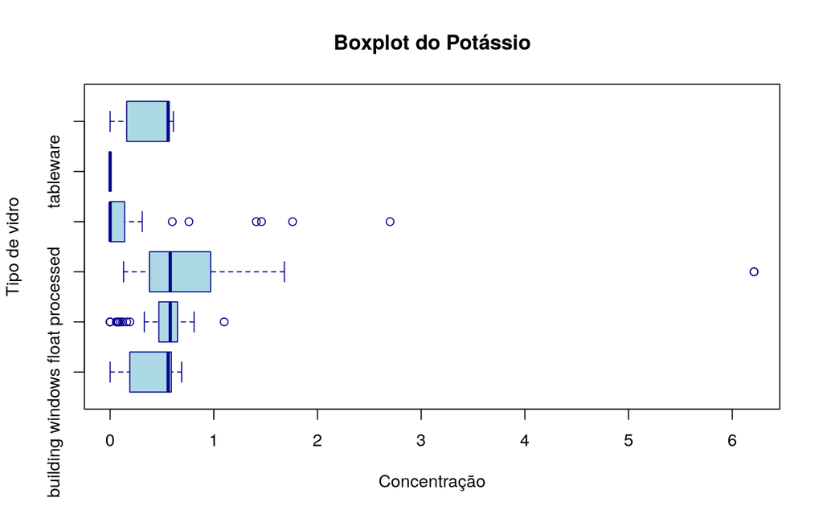

```r
# Boxplot para o Potássio em relação ao tipo de vidro
boxplot(K ~ tipo_vidro,
        data = glass_df,
        main = "Boxplot do Potássio",
        xlab = "Concentração",
        ylab = "Tipo de vidro",
        col = "lightblue",
        border = "darkblue",
        horizontal = TRUE)
```

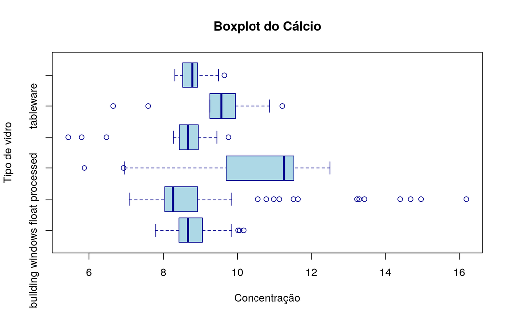

```r
# Boxplot para o Cálcio em relação ao tipo de vidro
boxplot(Ca ~ tipo_vidro,
        data = glass_df,
        main = "Boxplot do Cálcio",
        xlab = "Concentração",
        ylab = "Tipo de vidro",
        col = "lightblue",
        border = "darkblue",
        horizontal = TRUE)
```

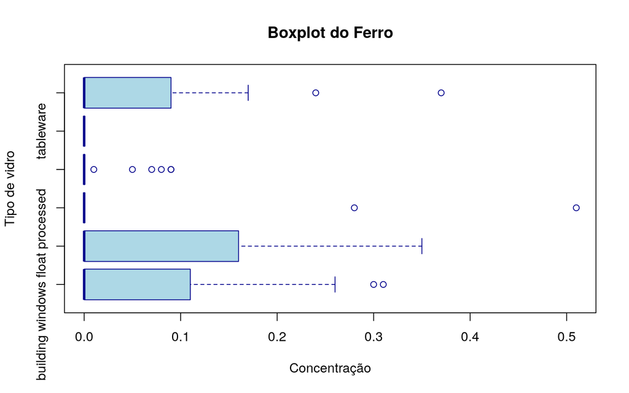

```r
# Boxplot para o Ferro em relação ao tipo de vidro
boxplot(Fe ~ tipo_vidro,
        data = glass_df,
        main = "Boxplot do Ferro",
        xlab = "Concentração",
        ylab = "Tipo de vidro",
        col = "lightblue",
        border = "darkblue",
        horizontal = TRUE)
```

A partir da análise dos boxplots, observa-se que, para a maioria dos elementos químicos, existem valores extremos (outliers) dentro dos próprios grupos de vidro. No contexto da análise de clustering, a remoção de outliers deve ser feita de forma criteriosa, considerando não apenas critérios estatísticos, mas também o seu significado químico e o impacto na discriminação entre clusters.

No caso do potássio, verifica-se a presença de duas observações com concentrações anormalmente elevadas no grupo dos vidros do tipo *containers*. De acordo com a literatura, este tipo de vidro apresenta, em geral, baixos teores de potássio, embora existam casos pontuais que se afastam da composição típica. Neste contexto, considerou-se que estes valores extremos poderiam introduzir ruído e enviesar o processo de clustering. Assim, estes outliers foram considerados prejudiciais à análise e removidos do conjunto de dados.

Relativamente aos restantes outliers identificados, considerou-se que estes desempenham um papel relevante na discriminação entre os diferentes tipos de vidro, uma vez que correspondem a variações químicas semanticamente válidas e associadas a propriedades específicas de cada tipo de vidro. Assim, a sua remoção poderia comprometer a capacidade do algoritmo de clustering em identificar grupos distintos

## 4.4 Heatmap e Correlação das Variáveis Independentes

A definição de correlação permite-nos descobrir as correlações de diferentes variáveis independentes entre os diferentes tipos de vidro. Uma alta correlação, positiva ou negativa, entre duas variáveis sugere que ambas contribuem com o mesmo para o cálculo de distâncias entre grupos.

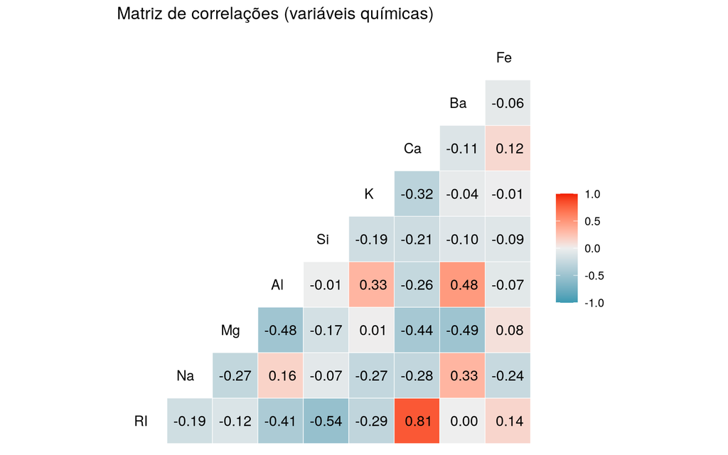

```r
# Matriz de correlações
GGally::ggcorr(glass_dfp, label = TRUE, label_round = 2, hjust = 0.75) +
  ggtitle("Matriz de correlações (variáveis químicas)")
```

A análise da matriz de correlações revelou que o índice de refração (RI) apresenta uma forte correlação com o teor de cálcio (Ca). Considerando este elevado grau de associação, optou-se por remover o índice de refração da análise, privilegiando a utilização do cálcio, por se tratar de uma variável química direta. Esta decisão permite focar a análise nos componentes químicos, e assim facilitando a interpretação dos resultados.

## 4.5 Conclusões sobre a Análise Exploratória dos Dados

Após a utilização de diferentes testes e diferentes estratégias para entender o conjunto de dados, retirámos as seguintes conclusões essenciais, que serão utilizadas na criação do modelo de K-Means:

1. O elemento químico ferro, Fe, e o bário, Ba, **serão removidos do dataset.**
2. O índice de refração **será removido do dataset**, isto pois apresenta uma alta correlação com o cálcio.
3. **Valores de potássio superiores a 6% no tipo de vidro *containers* foram removidos,** de forma a melhorar a discriminação entre clusters.

# 5. Determinação do Número Ótimo de Clusters

Antes de aplicar o algoritmo K-Means, é fundamental determinar o número adequado de grupos (clusters) a utilizar e preparar cuidadosamente os conjuntos de dados que serão analisados.

## 5.1 Separação de features e padronização dos dados

Antes de determinar o número ótimo de clusters, decidimos aplicar as transformações propostas no último capítulo e assim criar um dataset com/sem a variável dependente. Apenas as variáveis independentes são usadas no algoritmo de K-Means.

As diferentes variáveis independentes, possuem diferentes escalas, e por isso é necessário proceder à padronização das mesmas. A padronização dos dados facilita na intrepretação dos resultados obtidos.

```r
# Datasets utilizados para o modelo
# O model já inclui as mudanças feitas na análise exploratória de dados

glass_model <- glass_df %>% select(Na, Mg, Al, Si, K, Ca, tipo_vidro)
glass_model <- glass_model[glass_model$K <= 6, ]

glass_features <- glass_model %>% select(-tipo_vidro)

# Padronização dos dados
glass_scaled <- scale(glass_features)
glass_scaled <- as.data.frame(glass_scaled)
scale_params <- list(
  center = attr(glass_scaled, "scaled:center"),
  scale = attr(glass_scaled, "scaled:scale")
)
```

## 5.2 Determinação do Número Ótimo de Clusters

Para determinar o número ótimo de clusters a utilizar, utilizámos uma metodologia com as seguintes três fases:

### 5.2.1 Visualização de Heatmap de Distâncias Euclideanas

O heatmap apresenta a matriz de distâncias euclidianas entre as amostras, onde a variação das cores reflete o grau de similaridade ou dissimilaridade entre elas. Regiões com cores mais claras ao longo da diagonal principal indicam alta similaridade — correspondendo a amostras próximas entre si. Já as cores mais escuras afastadas da diagonal representam maiores diferenças entre as amostras. Esta visualização facilita a identificação visual de possíveis agrupamentos naturais no conjunto de dados.

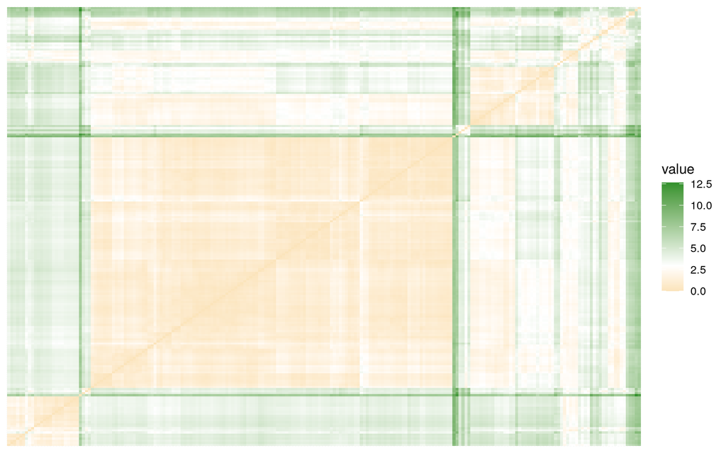

```r
# Gráfico de distâncias euclidenas

eucl_dist <- dist(glass_scaled, method= "euclidean")

fviz_dist(
  eucl_dist,
  show_labels = FALSE,
  gradient = list(low = "#DBA902", mid = "white", high = "#32912C"),
  order = TRUE
)
```

### 5.2.2 Método do Cotovelo

Apesar do mapa de calor evidenciar quatro grupos distintos, é sempre necessário verificar o resultado do método do cotovelo. Tendo em conta o valor obtido anteriormente e a cardinalidade da variável dependente, decidimos utilizar o método do cotovelo entre os valores de 1 a 10. Considerámos este intervalo suficiente para encontrar um número de ótimo de clusters.

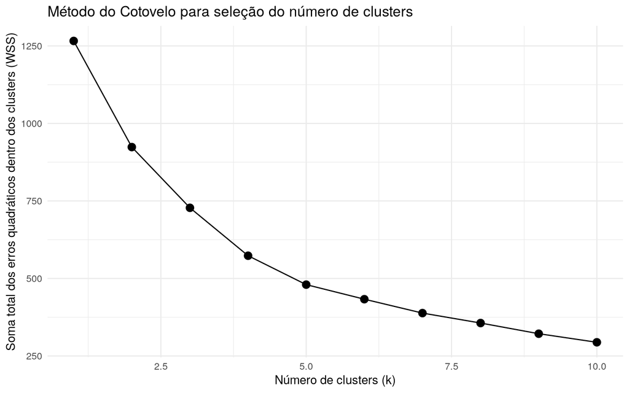

```r
k_grid <- 1:10
wss_df <- tibble(
  k = k_grid,
  tot_wss = map_dbl(k_grid, ~ kmeans(glass_scaled, centers = .x, nstart = 50)$tot.withinss)
)

ggplot(wss_df, aes(x = k, y = tot_wss)) +
  geom_point(size = 3) +
  geom_line() +
  labs(
    title = "Método do Cotovelo para seleção do número de clusters",
    x = "Número de clusters (k)",
    y = "Soma total dos erros quadráticos dentro dos clusters (WSS)"
  ) +
  theme_minimal()
```

A análise do método do cotovelo indica que o número ideal de clusters situa-se entre **k = 4** e **k = 5**. Observa-se no gráfico que, a partir de **k = 5**, a redução na soma dos erros quadráticos dentro dos clusters (WSS) torna-se menos pronunciada, sugerindo que a adição de clusters além deste ponto proporciona ganhos marginais na explicação da variabilidade dos dados.

### 5.2.3 Método de Silhueta

Após o método de cotovelo definir que o número ótimo de agrupamentos se encontraria entre quatro ou cinco, decidimos validar e escolher o número ótimos entre ambos através de uma análise de silhueta.

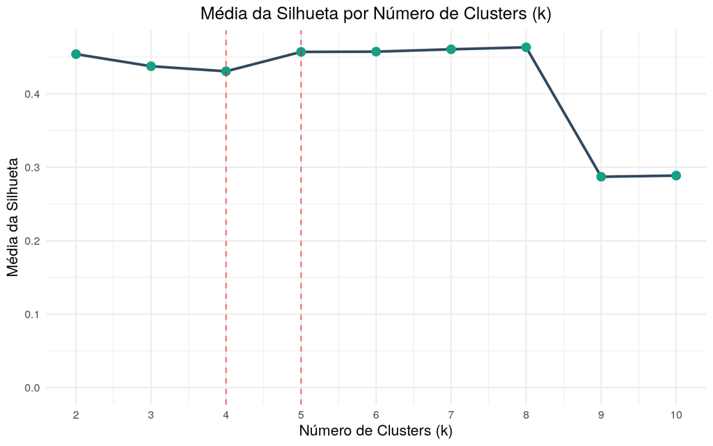

```r
sil_df <- map_dfr(2:10, function(k) {
  set.seed(123)
  km <- kmeans(glass_scaled, centers = k, nstart = 50)
  sil <- silhouette(km$cluster, dist(glass_scaled))
  tibble(k = k, sil_mean = mean(sil[, "sil_width"]))
})

ggplot(sil_df, aes(x = k, y = sil_mean)) +
  geom_line(color = "#34495e", size = 1) +
  geom_point(size = 3, color = "#16a085") +
  geom_vline(xintercept = c(4, 5), linetype = "dashed", color = "red", alpha = 0.6) +
  scale_x_continuous(breaks = 1:10) +
  labs(
    title = "Média da Silhueta por Número de Clusters (k)",
    x = "Número de Clusters (k)",
    y = "Média da Silhueta"
  ) +
  expand_limits(y = 0) +
  theme_minimal() +
  theme(
    plot.title = element_text(size = 14, hjust = 0.5),
    axis.title = element_text(size = 12)
  )
```

Através do gráfico de silhueta observa-se que a silhueta média atinge o maior valor em **k=8.** Considerando os resultados do método de cotovelo e análise de silhueta considerámos o valor **k=5**, no ponto certo em que consegue explicar o suficiente da coesão intra-estrutural do agrupamento e têm as suas diferenças em relação aos outros clusters. Também acaba por ser uma escolha mais conservadora no número de clusters.

Após estas três fases decidimos que `k_opt` é igual a cinco.

```r
k_opt <- 5
```

# 6. Aplicação do Algoritmo K-Means

Nesta fase aplicamos o algoritmo de K-Means, com o número ótmo de clusters determinado no último capítulo. Além disso associamos os rótulos de cada cluster a cada observação do conjunto de dados original.

Durante a execução do algoritmo utilizamos o `nstart = 50`, de forma a evitar uma convergência para mínimos globais.

```r
set.seed(123)
km_model <- kmeans(glass_scaled, centers = k_opt, nstart = 50)
km_model$cluster
```

```
##   [1] 1 4 4 4 4 4 4 4 4 4 4 4 4 4 4 4 4 1 1 4 4 1 4 4 4 4 4 4 4 4 4 4 4 4 4 4 1
##  [38] 4 1 1 4 4 4 1 4 4 4 1 1 4 1 4 4 4 4 4 4 4 4 4 1 1 1 1 1 1 1 1 1 1 1 4 4 4
##  [75] 4 4 4 4 4 4 4 4 4 4 2 4 4 4 4 4 4 4 4 4 4 4 4 4 4 4 4 4 4 1 1 3 3 3 3 3 3
## [112] 3 3 4 4 4 4 4 4 4 4 4 4 4 4 4 4 1 4 1 3 3 4 4 4 4 4 4 4 4 4 4 4 4 4 4 1 4
## [149] 4 4 4 1 1 4 4 4 4 1 4 4 4 1 1 2 4 3 3 3 3 3 3 3 4 3 1 1 1 1 5 5 5 3 5 2 2
## [186] 4 1 1 5 5 5 5 5 5 5 5 5 5 5 2 5 5 5 5 5 2 5 5 5 5 5 5
```

```r
glass_clustered <- glass_model %>%
  mutate(cluster = factor(km_model$cluster))
```

# 7. Análise e Interpretação dos Perfis Químicos

Após a execução do algoritmo, os resultados foram analisados de forma a identificar os elementos químicos com maior contributo para a separação entre clusters, permitindo a caracterização química de cada grupo identificado.

## 7.1 Média das Variáveis de Composição Química dos Clusters

Para interpretar os resultados obtidos no capítulo anterior calculámos as médias gerais por cluster, de forma a perceber diferenças estruturais entre os tipos de vidro e tipos de elementos químicos que podem conter.

Calculamos as médias das variáveis químicas originais por cluster para obter um perfil interpretável em unidades reais.

```r
cluster_profile <- glass_clustered %>%
  group_by(cluster) %>%
  summarise(across(Na:Ca, mean, .names = "mean_{.col}"), n = n(), .groups = "drop")

knitr::kable(cluster_profile, caption = "Médias das variáveis químicas por cluster (escala original)")
```

Médias das variáveis químicas por cluster (escala original)

| cluster | mean_Na | mean_Mg | mean_Al | mean_Si | mean_K | mean_Ca | n |
| --- | --- | --- | --- | --- | --- | --- | --- |
| 1 | 13.92447 | 3.3573684 | 1.023158 | 71.87316 | 0.1544737 | 9.471053 | 38 |
| 2 | 13.76833 | 2.0383333 | 2.103333 | 72.37833 | 1.6850000 | 6.595000 | 6 |
| 3 | 12.66737 | 0.2594737 | 1.308421 | 72.59579 | 0.3073684 | 12.481053 | 19 |
| 4 | 13.08569 | 3.4589431 | 1.391545 | 72.80740 | 0.5829268 | 8.445447 | 123 |
| 5 | 14.66538 | 0.1653846 | 2.139615 | 73.30923 | 0.0165385 | 8.750000 | 26 |

## 7.2 Classificação Química dos Clusters

Através dos resultados obtidos podemos classificar os diferentes clusters de acordo com as seguintes diretrizes:

- **Cluster 1** - O primeiro cluster tem um alto teor de magnésio, muito semelhante ao cluster 4, mas apresenta um nível de cálcio mais elevado. Este é o segundo maior cluster em número de elementos, o que sugere um tipo de vidro comum, em vez de um vidro especializado.
- **Cluster 2** - O segundo cluster destaca-se como o mais especializado da amostra. O seu perfil químico é definido por um elevado teor de potássio em contraste com uma baixa concentração de cálcio, características que o distinguem claramente das restantes categorias.
- **Cluster 3** -O terceiro cluster distingue-se pelo seu elevado teor de cálcio, o mais expressivo de todos os grupos. Esta composição é igualmente caracterizada por concentrações mínimas de magnésio e sódio, o que reforça a sua singularidade química.
- **Cluster 4** - O quarto cluster, à semelhança do primeiro, apresenta uma elevada concentração de magnésio; contudo, distingue-se por possuir teores de sódio e cálcio inferiores. Sendo o grupo mais numeroso, este perfil de vidro pode estar fortemente associado aos vidros normais de construção.
- **Cluster 5** - O quinto cluster, representa o tipo de vidros com maior teor em sódio. Este também se distingue dos restantes por ter um teor magnesiano quase nulo. Este perfil de vidro é normalmente associado a faróis de automóveis.

## 7.3 Visualizações de separação dos clusters

Para além da interpretação dos resultados e da definição dos perfis químicos de cada cluster, é fundamental visualizar a informação através de uma projeção por Análise de Componentes Principais (PCA). Esta abordagem permite observar a sobreposição entre clusters, assim como o grau de separação e afastamento entre eles, facilitando a compreensão visual da estrutura dos dados.

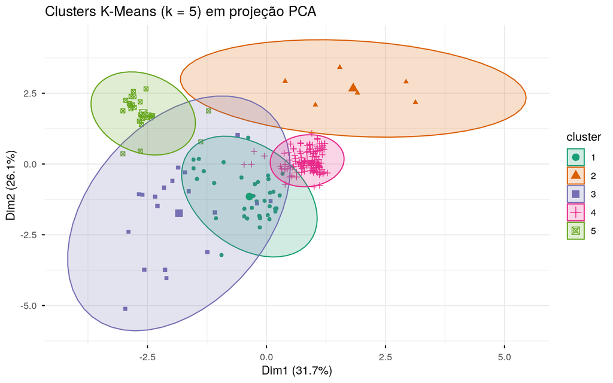

```r
fviz_cluster(
  km_model,
  data = glass_scaled,
  geom = "point",
  ellipse.type = "norm",
  palette = "Dark2",
  ggtheme = theme_minimal()
) +
  labs(title = "Clusters K-Means (k = 5) em projeção PCA")
```

A projeção por Análise de Componentes Principais (PCA) revela uma separação clara dos clusters 1 e 5, destacando-se principalmente a diferença nas concentrações de magnésio entre eles. Observa-se que os clusters 1, 4 e 5 apresentam menor dispersão interna, o que facilita a identificação consistente das suas propriedades químicas. Conforme antecipado na análise anterior, os clusters 1 e 4 encontram-se muito próximos, com uma ligeira sobreposição, refletindo similaridades químicas. Por outro lado, o cluster 2 destaca-se como o mais especializado, evidenciado pela maior dispersão dos seus pontos, que compartilha algumas características com o cluster 3. Esta proximidade pode ser atribuída ao valor semelhante de sílica (Si) observado em ambos os grupos, sugerindo uma relação química que justifica a sobreposição na projeção.

Além da visualização no plano por PCA, geramos gráficos de dispersão bivariada com cores por cluster, de forma a verificar as diferenças entre clusters num plano químico específico. Fizemos as seguintes comparações para responder a diferentes perguntas:

### 7.3.1 Comparação entre o Sódio e o Cálcio

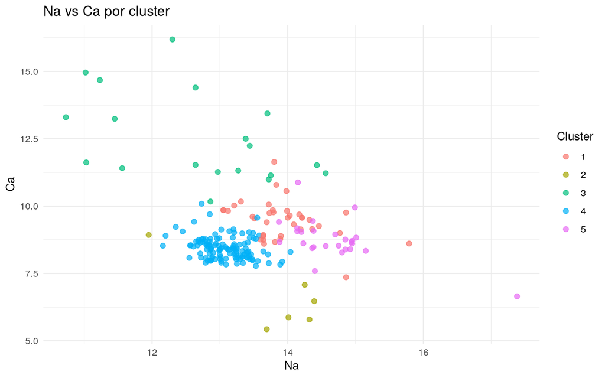

```r
glass_clustered %>%
  ggplot(aes(x = Na, y = Ca, color = cluster)) +
  geom_point(alpha = 0.7, size = 2) +
  labs(title = "Na vs Ca por cluster", color = "Cluster")
```

Através da análise do gráfico, observa-se que o terceiro cluster apresenta um perfil altamente especializado, posicionando-se como um *outlier* em relação aos restantes grupos. Esta segregação é impulsionada pela combinação singular de uma baixa concentração de sódio (Na) com um teor elevadíssimo de cálcio (Ca). Por outro lado, tal como verificado na análise de PCA, o cluster 1 exibe uma sobreposição significativa com outros agrupamentos, o que dificulta a definição precisa da sua tipologia de vidro com base apenas nestas variáveis.

### 7.3.2 Comparação entre o Magnésio e o Alumínio

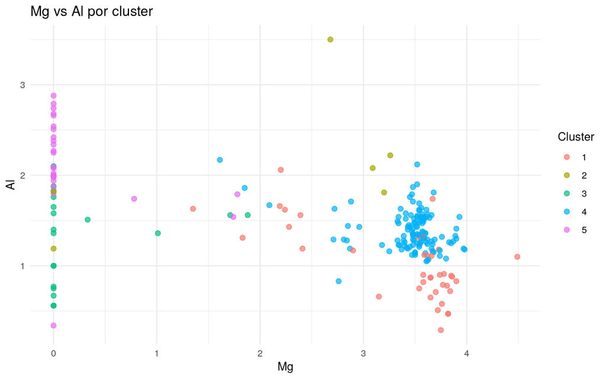

```r
glass_clustered %>%
  ggplot(aes(x = Mg, y = Al, color = cluster)) +
  geom_point(alpha = 0.7, size = 2) +
  labs(title = "Mg vs Al por cluster", color = "Cluster")
```

Este gráfico evidencia uma divisão clara entre dois grandes grupos: os clusters com teores residuais de magnésio e aqueles em que este elemento é predominante. A análise revela que o **cluster 5** possui um teor de magnésio quase nulo que, aliado aos elevados níveis de sódio, é consistente com o perfil químico dos **faróis (headlamps)**.

Uma coisa muito importante e que se verifica aqui é a distinção entre dois grupos distintos de vidros com magnésio elevado. Ambos os clusters 1 e 4, têm magnésio elevado mas distinguem-se maioritariamente nas suas concentrações de alumínio. Sendo estes dois clusters os com mais elementos no dataset sugere a distinção entre vidros de janela com float e sem float.

# 8. Validação com `tipo_vidro`

Criamos uma tabela cruzada (confusão) entre os clusters obtidos e os tipos de vidro originais. Também calculamos a proporção principal por cluster para perceber pureza.

```r
confusion_tbl <- glass_clustered %>%
  count(cluster, tipo_vidro) %>%
  group_by(cluster) %>%
  mutate(prop_cluster = n / sum(n)) %>%
  arrange(cluster, desc(prop_cluster))

knitr::kable(confusion_tbl, caption = "Tabela cruzada: cluster vs tipo de vidro")
```

Tabela cruzada: cluster vs tipo de vidro

| cluster | tipo_vidro | n | prop_cluster |
| --- | --- | --- | --- |
| 1 | building windows float processed | 21 | 0.5526316 |
| 1 | vehicle windows float processed | 6 | 0.1578947 |
| 1 | building windows non float processed | 5 | 0.1315789 |
| 1 | tableware | 4 | 0.1052632 |
| 1 | headlamps | 2 | 0.0526316 |
| 2 | headlamps | 4 | 0.6666667 |
| 2 | building windows non float processed | 1 | 0.1666667 |
| 2 | containers | 1 | 0.1666667 |
| 3 | building windows non float processed | 10 | 0.5263158 |
| 3 | containers | 8 | 0.4210526 |
| 3 | tableware | 1 | 0.0526316 |
| 4 | building windows non float processed | 60 | 0.4878049 |
| 4 | building windows float processed | 49 | 0.3983740 |
| 4 | vehicle windows float processed | 11 | 0.0894309 |
| 4 | containers | 2 | 0.0162602 |
| 4 | headlamps | 1 | 0.0081301 |
| 5 | headlamps | 22 | 0.8461538 |
| 5 | tableware | 4 | 0.1538462 |

Leituras da tabela cruzada:

Para sintetizar o grau de pureza de cada grupo, calculamos a proporção do tipo de vidro dominante em cada cluster.

```r
cluster_purity <- confusion_tbl %>%
  group_by(cluster) %>%
  summarise(
    n_cluster = sum(n),
    tipo_dominante = tipo_vidro[which.max(n)],
    n_dominante = max(n),
    pureza = n_dominante / n_cluster,
    .groups = "drop"
  ) %>%
  arrange(desc(pureza))

overall_purity <- sum(cluster_purity$n_dominante) / sum(cluster_purity$n_cluster)

knitr::kable(cluster_purity, digits = 3, caption = "Pureza por cluster (proporção do tipo dominante)")
```

Pureza por cluster (proporção do tipo dominante)

| cluster | n_cluster | tipo_dominante | n_dominante | pureza |
| --- | --- | --- | --- | --- |
| 5 | 26 | headlamps | 22 | 0.846 |
| 2 | 6 | headlamps | 4 | 0.667 |
| 1 | 38 | building windows float processed | 21 | 0.553 |
| 3 | 19 | building windows non float processed | 10 | 0.526 |
| 4 | 123 | building windows non float processed | 60 | 0.488 |

Pureza global: 55.2% das observações caem no tipo dominante do respetivo cluster.

# 9. Conclusões